# Assignment 2 (Machine Learning)

Abhishek Bhatia

27th February 2019

Assignment 2  
Use the data.csv file for two class two feature problem 1373 data points. Seperate the first 100 data points from each of the classes (0 and 1) for testing and the remaining data points for training.  
Load the data

```r
df <- read.csv('data/data.csv')
head(df)
```

```
##        x1      x2 class
## 1  8.6661 -2.8073     0
## 2  8.1674 -2.4586     0
## 3 -2.6383  1.9242     0
## 4  9.5228 -4.0112     0
## 5 -4.4552  4.5718     0
## 6  9.6718 -3.9606     0
```

```r
test.rows <- 1:100
test <- Reduce(rbind, lapply(c(0, 1),
                             function (i) subset(df, class == i)[test.rows, ]))
train.rows <- -as.numeric(rownames(test))
train <- df[train.rows, ]
```

Make the data matrix

```r
X <- as.matrix(train[, 1:2])
```

Within class scatter function

```r
within.class.scatter <- function(X, method=c('slow', 'fast')){
  method = match.call()
  if (method == 'fast') return (cov(X)*(nrow(X) -1))

  mu <- as.numeric(colMeans(X))
  Sw <- 0
  n <- nrow(X)
  for (i in 1:n){
    x_mu <- as.numeric(X[i, ] - mu)
    Sw <- Sw + x_mu %*% t(x_mu)
  }

  return(Sw)
}
```

1. Report the mean and scatter of both the classes. [4]

```r
# Get the unique classes
y.uniq <- unique(df[, "class"])

# This list will store the results
res <- list(mean=list(), scatter=list())
Sw <- 0
for (lab in y.uniq){
  s <- subset(df, class == lab)[, -3]
  lab <- as.character(lab)
  res$mean[[lab]] <- matrix(as.numeric(colMeans(s)), 2, 1)
  res$scatter[[lab]] <- within.class.scatter(s, "fast")

  Sw <- Sw + res$scatter[[lab]]
}

res
```

```
## $mean
## $mean$`0`
##          [,1]
## [1,] 4.256627
## [2,] 0.796718
##
## $mean$`1`
##            [,1]
## [1,] -0.9935761
## [2,]  2.1482710
##
##
## $scatter
## $scatter$`0`
##           [,1]      [,2]
## [1,] 20095.867 -9511.867
## [2,] -9511.867  7988.150
##
## $scatter$`1`
##           [,1]      [,2]
## [1,]  17790.58 -15374.02
## [2,] -15374.02  16861.17
```

2. Find the direction (v) which maximizes the separation of the classes using LDA. [2]

```r
diff.means <- res$mean[["0"]] - res$mean[["1"]]
v <- solve(Sw) %*% (diff.means)
```

3. Project all training data points onto v and create your own decision rule. Write as comment in your code about the decision criterion. In the overlapping region on the projected line you can randomly predict the classes. [8]

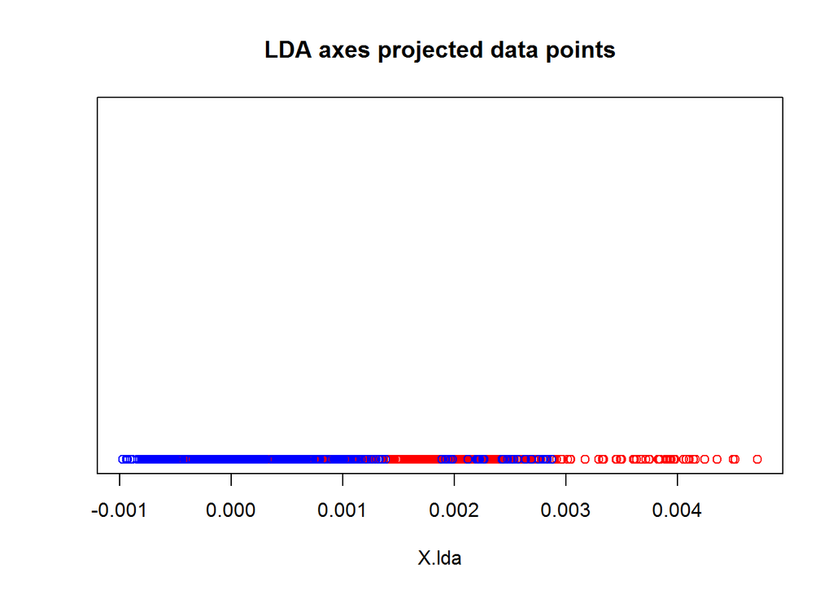

```r
X.lda <- X %*% v
colors <- character(length(train[, 3]))
colors[train[, 3] == 0] <- "red"
colors[train[, 3] == 1] <- "blue"

colors <- c("red", "blue")[train[, 3] + 1]

plot(X.lda, rep(0, length(X.lda)), col= colors, yaxt="n", ylab="",
     main="LDA axes projected data points",
     ylim=c(0, 10))
```

Slightly shifted version to clearly see the overlapping points

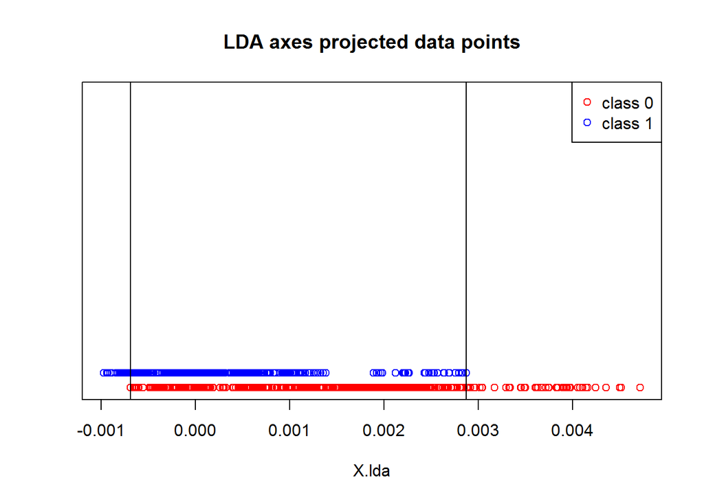

```r
plot(X.lda, train[, 3], col= colors, ylim = c(0, 20),
     main="LDA axes projected data points", ylab="", yaxt="n")
legend("topright",
       paste("class", y.uniq),
       col=c("red", "blue"),
       pch=1)

r <- X.lda[colors == "red", ]
l <- X.lda[colors == "blue", ]
dcsn.bndrs <- c(min(r), max(l))
# plot the decision boundaries
abline(v=dcsn.bndrs)
```

The rule for the decision:

```r
paste('if the the coordinate of the projected point on the lda is',
    'less than', dcsn.bndrs[1], "predict = 1")
```

```
## [1] "if the the coordinate of the projected point on the lda is less than -0.000686728873456477 predict = 1"
```

```r
cat('if the the coordinate of the projected point on the lda is',
    'greater than', dcsn.bndrs[2], "predict = 0")
```

```
## if the the coordinate of the projected point on the lda is greater than 0.002870464 predict = 0
```

```r
cat('Else randomly predict 0 or 1 with equal probability')
```

```
## Else randomly predict 0 or 1 with equal probability
```

```r
pred.func <- function(x){
  ifelse(x < dcsn.bndrs[1], 1,
         ifelse(x > dcsn.bndrs[2], 0,
                sample(y.uniq)))

}

# Make the test and train subsets
X.train.lda <- X.lda
X.test <- as.matrix(test[, 1:2])
X.test.lda <- X.test %*% v
cl <- train[, 3]
test.true <- test[, 3]

# Accuracy function
accuracy <- function(y.true, y.pred){
  return(mean(y.true == y.pred))
}

# Evaluate the crude decision criteria
test.preds.crude <- pred.func(X.test.lda)
cnf.mat <- table(test.preds.crude, test.true)
acc.crude <- accuracy(test.true, test.preds.crude)
paste("The accuracy for the crude decision criteria is", acc.crude)
```

```
## [1] "The accuracy for the crude decision criteria is 0.525"
```

How does the Discriminant axes look like in the 2D scatter plot ?

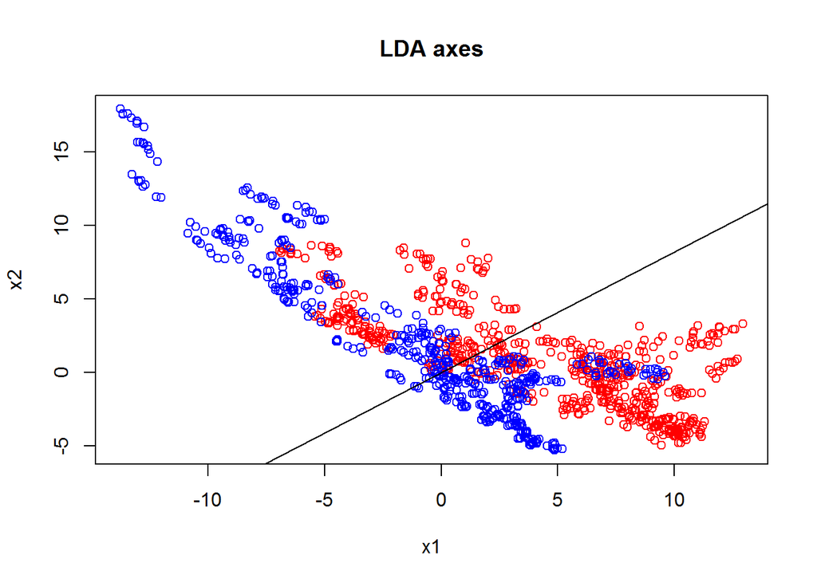

```r
plot(X, col=colors, main="LDA axes")
abline(a=0, b=v[2]/v[1])
```

How does the crude decision boundary look in the 2D scatter plot?

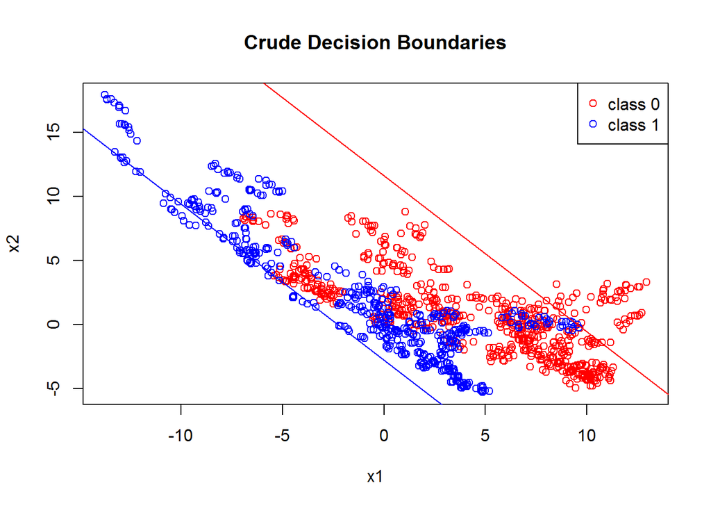

```r
draw.lda.pt <- function(x, col){
  a <- x/v[2]
  b <- -v[1]/v[2]
  abline(a, b, col=col)
}
plot(X, col=colors, main="Crude Decision Boundaries")
draw.lda.pt(dcsn.bndrs[1], col="blue")
draw.lda.pt(dcsn.bndrs[2], col="red")
legend("topright",
       paste("class", y.uniq),
       col=c("red", "blue"),
       pch=1)
```

5. Perform KNN on the projected data points for k=5 to predict the classes of the 200 test points. Report the accuracy with confusion matrix.[2]

```r
library(class)

k <- 5
test.preds.knn <- knn(X.train.lda, X.test.lda, cl, k = k)
cnf.mat <- table(test.preds.knn, test.true)
cnf.mat
```

```
##               test.true
## test.preds.knn  0  1
##              0 78 30
##              1 22 70
```

```r
acc.knn <- accuracy(test.true, test.preds.knn)
paste("The accuracy for knn with k =",  k, "is", acc.knn)
```

```
## [1] "The accuracy for knn with k = 5 is 0.74"
```

Would modelling them as gaussians help?

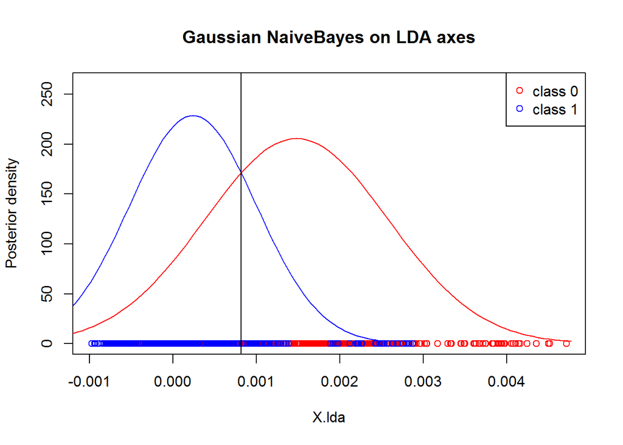

```r
n.l <- length(l)
n.r <- length(r)

mu.l <- mean(l)
sd.l <- sd(l)
prior.l <- n.l/(n.l + n.r)

mu.r <- mean(r)
sd.r <- sd(r)
prior.r <- n.r/(n.l + n.r)

d1 <- function(x){
  dnorm(x, mu.l, sd.l)*prior.l
}

d2 <- function(x){
  dnorm(x, mu.r, sd.r)*prior.r
}
ylim.max <- max(d1(0), d2(0))*1.2
plot(X.lda, rep(0, length(X.lda)), col= colors, ylim = c(0, ylim.max),
     ylab="Posterior density", main="Gaussian NaiveBayes on LDA axes")
legend("topright",
       paste("class", y.uniq),
       col=c("red", "blue"),
       pch=1)



curve(d1, add=T, mu.l - 3*sd.l, mu.l + 3*sd.l , col="blue")
curve(d2, add=T, mu.r - 3*sd.r, mu.r + 3*sd.r , col="red")

# Find and plot the decision boundary
dcsn.bndry <- uniroot(function (x) d1(x) - d2(x), interval = c(0, 0.002),
                      tol = 1e-5)$root
abline(v=dcsn.bndry)
```

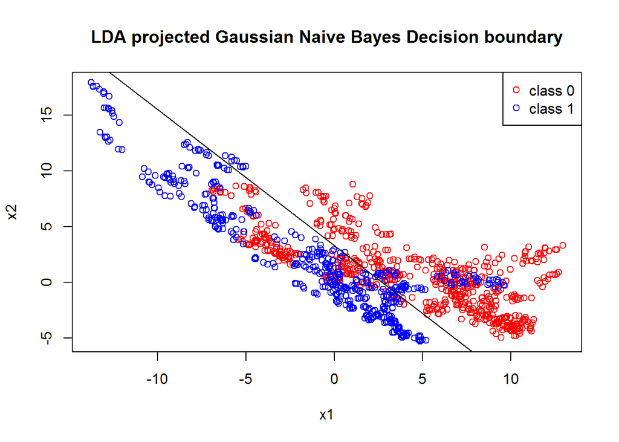

```r
# How does this decision boundary look in the 2 dimensions?
plot(X, col=colors, main="LDA projected Gaussian Naive Bayes Decision boundary")
a <- dcsn.bndry/v[2]
b <- -v[1]/v[2]
abline(a, b)
legend("topright",
       paste("class", y.uniq),
       col=c("red", "blue"),
       pch=1)
```